# Profiling Models

## Measurement Paramenters

- Common
  - OMP_NUM_THREADS=12
  - Sigle Process
- Fugaku
  - A64FX @ 2GHzMKL
  - 1CMG(numactl--cpunodebind=5 --membind=5(12 Core/CMG))
  - PyTorch : v1.4.0 + SSL + DNNL_Aarch64(SSL)
  - Disable LargePage
- Intel
  - Xeon Platinum 8268 @ 2.9GHz
  - 1Node (numactl--cpunodebind=0 --membind=0(24 Core/node))
  - PyTorch : v1.4.0 + DNNL
  - Disable Hyper Thread
  - HugePage : always

## Index

- Summary
- 1. rnn_rnn
  - 1-1. API Profile : rnn_rnn Evaluation
  - 1-2. API Profile : rnn_rnn Training
  - 1-3. API Profile : rnn_rnn Evaluation with shape
  - 1-4. API Profile : rnn_rnn Training with shape
  - 1-5. MKLDNN Profile : rnn_rnn Evaluation
  - 1-6. MKLDNN Profile : rnn_rnn Training
- 2. transformer_transformer
  - 2-1. API Profile : transformer_transformer Evaluation
  - 2-2. API Profile : transformer_transformer Training
  - 2-3. API Profile : transformer_transformer Evaluation with shape
  - 2-4. API Profile : transformer_transformer Training with shape
  - 2-5. MKLDNN Profile : transformer_transformer Evaluation
  - 2-6. MKLDNN Profile : transformer_transformer Training

# Summary

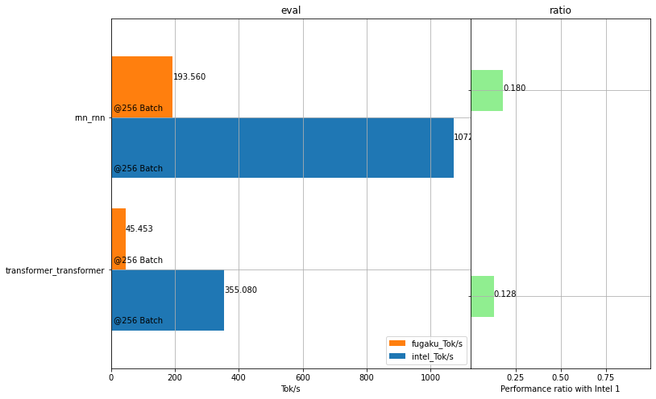

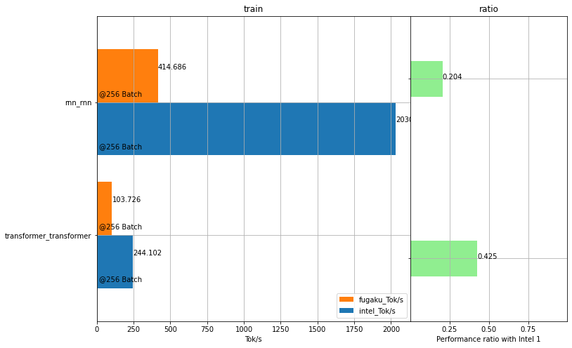

# 1. rnn_rnn

## 1-1. API Profile : rnn_rnn Evaluation

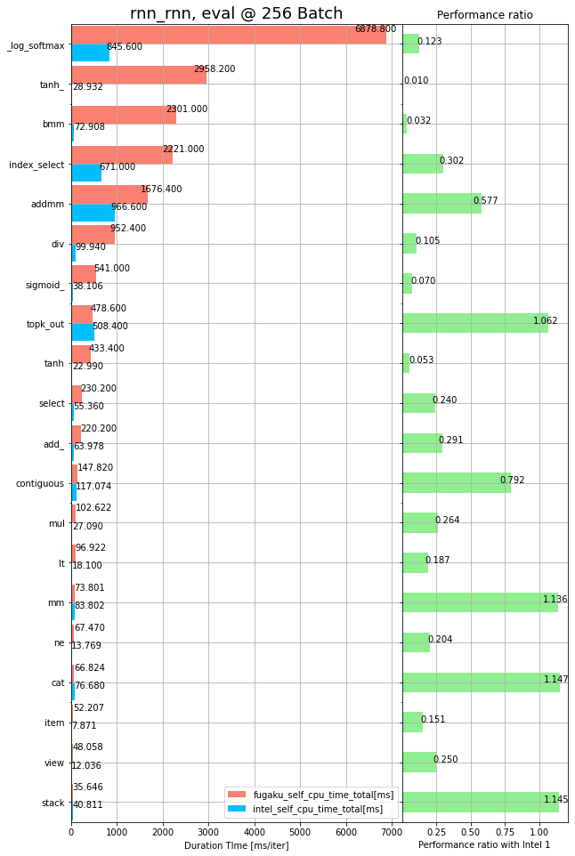

## 1-2. API Profile : rnn_rnn Training

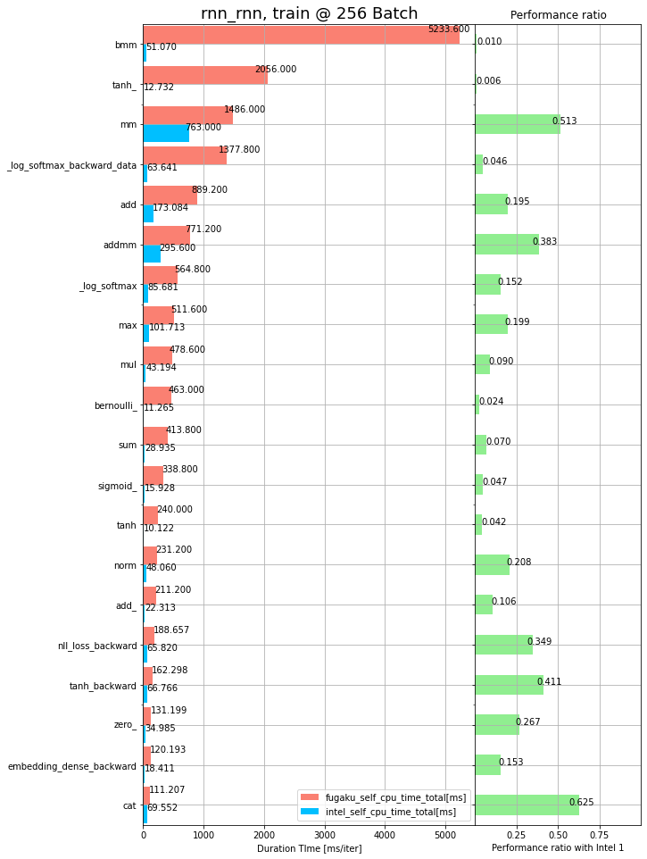

## 1-3. API Profile : rnn_rnn Evaluation with shape

[figure not shown]

## 1-4. API Profile : rnn_rnn Training with shape

cannot compare

## 1-5. MKLDNN Profile : rnn_rnn Evaluation

This Model don't use mkldnn API.

## 1-6. MKLDNN Profile : rnn_rnn Training

This Model don't use mkldnn API.

# 2. transformer_transformer

## 2-1. API Profile : transformer_transformer Evaluation

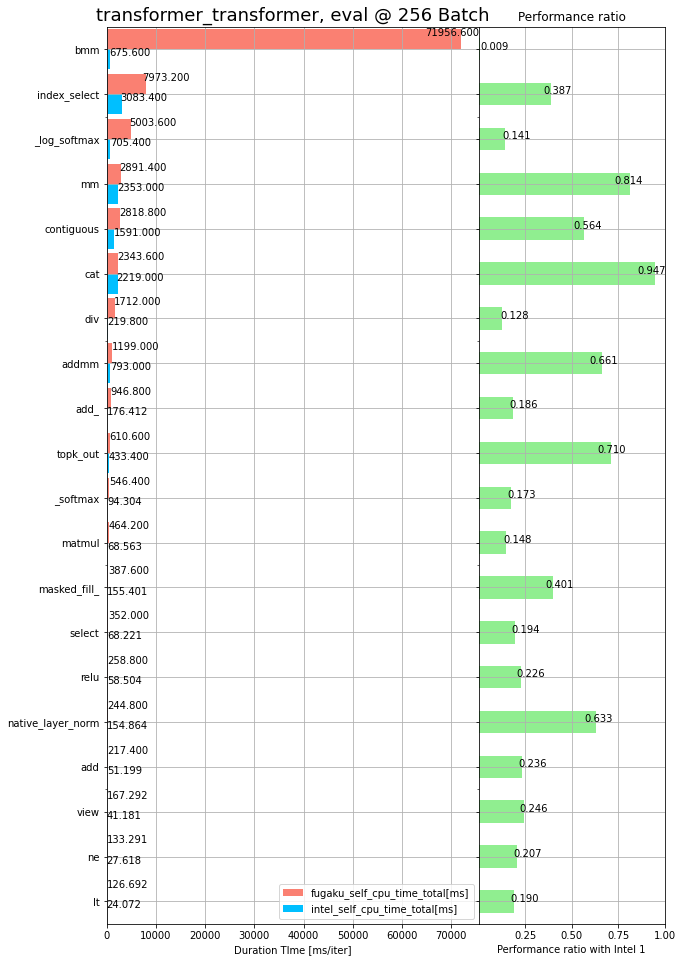

## 2-2. API Profile : transformer_transformer Training

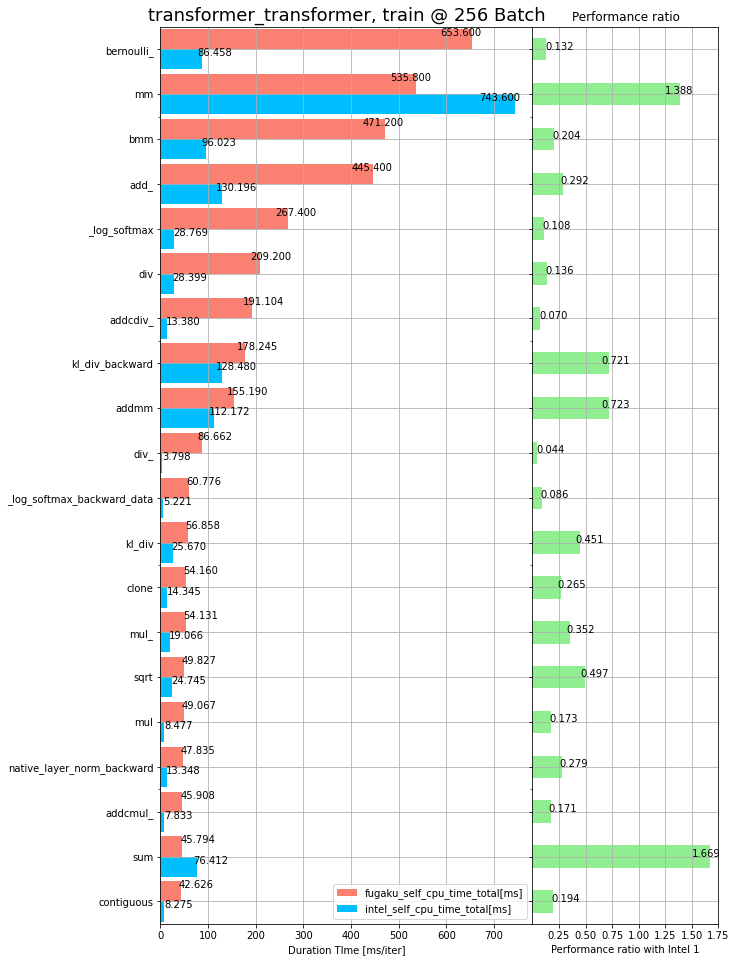

## 2-3. API Profile : transformer_transformer Evaluation with shape

[figure not shown]

## 2-5. MKLDNN Profile : transformer_transformer Evaluation

This Model don't use mkldnn API.

## 2-6. MKLDNN Profile : transformer_transformer Training

This Model don't use mkldnn API.